# 羅密歐與茱麗葉關鍵字分析

曹書誠

2018年4月13日

```r
library(NLP)
library(tm)
library(stats)
library(proxy)
library(dplyr)
library(readtext)
library(jiebaRD)
library(jiebaR)
library(slam)
library(Matrix)
library(tidytext)
```

```r
library(ggplot2)
library(gridExtra)
```

# 前言：

羅密歐與茱麗葉是起承轉合明確、人物設定鮮明的文學經典，且莎氏比亞的英語用字選詞，顯著地影響了近代英語。  
本project把羅密歐與茱蔍葉的文本，以幕數分割，先切詞組觀察有哪些高頻字詞，再從中挑出來八個詞做圖表分析。

# 讀入羅密歐與茱麗葉的文本（共一到五幕）

```r
rawData = readtext(file=c(
  "/Users/Eric/Documents/R study/Project_1/Act_1.txt",
  "/Users/Eric/Documents/R study/Project_1/Act_2.txt",
  "/Users/Eric/Documents/R study/Project_1/Act_3.txt",
  "/Users/Eric/Documents/R study/Project_1/Act_4.txt",
  "/Users/Eric/Documents/R study/Project_1/Act_5.txt"
))
docs = Corpus(VectorSource(rawData$text))
```

# 資料清洗

```r
toSpace <- content_transformer(function(x, pattern) {
  return (gsub(pattern, " ", x))
})
docs <- tm_map(docs, removePunctuation)
docs <- tm_map(docs, removeNumbers)
docs <- tm_map(docs, stripWhitespace)
```

# 切詞組，觀察哪些高頻字是有趣的

```r
keywords = c(" ")
mixseg = worker()
keys = as.matrix(keywords)
new_user_word(mixseg, keys)
```

```
## [1] TRUE
```

```r
jieba_tokenizer = function(d){
  unlist(segment(d[[1]], mixseg))
}
seg = lapply(docs, jieba_tokenizer)
freqFrame = as.data.frame(table(unlist(seg)))

d.corpus <- Corpus(VectorSource(seg))
tdm <- TermDocumentMatrix(d.corpus)
print( tf <- as.matrix(tdm) )
```

[output not shown]

[output cut: 3645 more lines]

[output not shown]

```r
DF <- tidy(tf)
```

# 用csv檔選出八個有興趣的關鍵字

我選出的八個有趣的關鍵字為love, death, night, heaven, romeo, juilet, benvolio, mercutio，  
選完後，再把選好的字的相關martrix讀入回來。

```r
write.csv(DF, "/Users/Eric/Documents/R study/Project_1//keywords_raw.csv")
DF_sec<-read.table("/Users/Eric/Documents/R study/Project_1//keywords_sec.csv",header=TRUE, stringsAsFactors = FALSE, sep=",")

print(DF_sec)
```

```
##   rownames love death night heaven romeo juliet benvolio mercutio
## 1        1   35     4    14      1    62     26       39       14
## 2        2   52     5    22      5   104     48       20       39
## 3        3   28    24    19     13    89     53       21       30
## 4        4   13    16    10      5     8     29        0        0
## 5        5    7    20     3      4    31     21        0        0
```

# 製成圖表

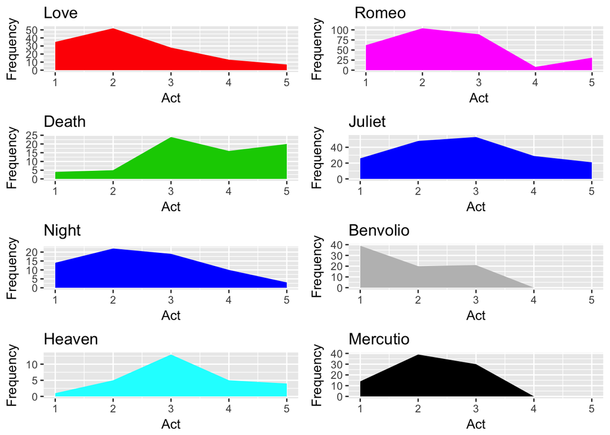

```r
g1=ggplot(data=DF_sec,aes(x=1:5,y=love)) +geom_area(fill=2)+xlab("Act")+ylab("Frequency")+ggtitle("Love")
g2=ggplot(data=DF_sec,aes(x=1:5,y=death)) +geom_area(fill=3)+xlab("Act")+ylab("Frequency")+ggtitle("Death")
g3=ggplot(data=DF_sec,aes(x=1:5,y=night)) +geom_area(fill=4)+xlab("Act")+ylab("Frequency")+ggtitle("Night")
g4=ggplot(data=DF_sec,aes(x=1:5,y=heaven)) +geom_area(fill=5)+xlab("Act")+ylab("Frequency")+ggtitle("Heaven")
g5=ggplot(data=DF_sec,aes(x=1:5,y=romeo)) +geom_area(fill=6)+xlab("Act")+ylab("Frequency")+ggtitle("Romeo")
g6=ggplot(data=DF_sec,aes(x=1:5,y=juliet)) +geom_area(fill=4)+xlab("Act")+ylab("Frequency")+ggtitle("Juliet")
g7=ggplot(data=DF_sec,aes(x=1:5,y=benvolio)) +geom_area(fill=8)+xlab("Act")+ylab("Frequency")+ggtitle("Benvolio")
g8=ggplot(data=DF_sec,aes(x=1:5,y=mercutio)) +geom_area(fill=9)+xlab("Act")+ylab("Frequency")+ggtitle("Mercutio")


finalchart=grid.arrange(g1,g5,g2,g6,g3,g7,g4,g8,nrow=4,ncol=2)
```

```r
print(finalchart)
```

# 結語

整理出圖表，左邊column為四個名詞（Love、Death、Night、Heaven），右邊為四個人名（羅密歐、茱麗葉、羅密歐的表哥、茱麗葉的表哥）。  
首先觀察名詞：  
一、Love在第二幕兩位主角初次相見時，使用次數達到高峰，但後來隨著劇情白熱化，使用次數其實逐漸下降，和一般認知的，Love使用次數會隨劇情發展而變多，並不相同。  
二、Death的兩次使用高峰為：第三幕兩大家族互殺（導致羅密歐的表哥、茱麗葉的表哥死亡），以及結尾兩大主角死亡。  
三、Night的使用次數在結尾時突然大幅減少，顯示了前幾幕的場景都為晚上，較為灰暗，而結尾的Good Ending時則不使用晚上場景，代表兩大家族大合解的曙光。  
四、Heaven的使用次數在羅密歐、茱麗葉兩人被迫分離的第三幕達到高峰，代表作者在此時大量暗示兩人最終只能在天堂相聚。  
接著觀察人名：  
一、羅密歐、茱麗葉：兩人在第五幕死後還有大量被提起，代表兩人的死並不是故事的結束。  
二、羅密歐的表哥、茱麗葉的表哥：兩人在第三幕死亡後，就一次都沒有被他人提起過了…明明是兩大家族各自的第一男配角的，這個發現令我感到驚奇。